# Capstone Project: Create a Customer Segmentation Report for Arvato Financial Services

In this project, you will analyze demographics data for customers of a mail-order sales company in Germany, comparing it against demographics information for the general population. You'll use unsupervised learning techniques to perform customer segmentation, identifying the parts of the population that best describe the core customer base of the company. Then, you'll apply what you've learned on a third dataset with demographics information for targets of a marketing campaign for the company, and use a model to predict which individuals are most likely to convert into becoming customers for the company. The data that you will use has been provided by our partners at Bertelsmann Arvato Analytics, and represents a real-life data science task.

The versions of those two datasets used in this project will include many more features and has not been pre-cleaned. You are also free to choose whatever approach you'd like to analyzing the data rather than follow pre-determined steps. In your work on this project, make sure that you carefully document your steps and decisions, since your main deliverable for this project will be a blog post reporting your findings.

```python
# import libraries here; add more as necessary
import numpy as np
import pandas as pd
import matplotlib.pyplot as plt
import seaborn as sns
sns.color_palette('Paired')

# magic word for producing visualizations in notebook
%matplotlib inline
```

## Part 0: Get to Know the Data

Each row of the demographics files represents a single person, but also includes information outside of individuals, including information about their household, building, and neighborhood. Use the information from the first two files to figure out how customers ("CUSTOMERS") are similar to or differ from the general population at large ("AZDIAS"), then use your analysis to make predictions on the other two files ("MAILOUT"), predicting which recipients are most likely to become a customer for the mail-order company.

The "CUSTOMERS" file contains three extra columns ('CUSTOMER_GROUP', 'ONLINE_PURCHASE', and 'PRODUCT_GROUP'), which provide broad information about the customers depicted in the file. The original "MAILOUT" file included one additional column, "RESPONSE", which indicated whether or not each recipient became a customer of the company. For the "TRAIN" subset, this column has been retained, but in the "TEST" subset it has been removed; it is against that withheld column that your final predictions will be assessed in the Kaggle competition.

Otherwise, all of the remaining columns are the same between the three data files. For more information about the columns depicted in the files, you can refer to two Excel spreadsheets provided in the workspace. One of them is a top-level list of attributes and descriptions, organized by informational category. The other is a detailed mapping of data values for each feature in alphabetical order.

In the below cell, we've provided some initial code to load in the first two datasets. Note for all of the `.csv` data files in this project that they're semicolon (`;`) delimited, so an additional argument in the [`read_csv()`](https://pandas.pydata.org/pandas-docs/stable/generated/pandas.read_csv.html) call has been included to read in the data properly. Also, considering the size of the datasets, it may take some time for them to load completely.

You'll notice when the data is loaded in that a warning message will immediately pop up. Before you really start digging into the modeling and analysis, you're going to need to perform some cleaning. Take some time to browse the structure of the data and look over the informational spreadsheets to understand the data values. Make some decisions on which features to keep, which features to drop, and if any revisions need to be made on data formats. It'll be a good idea to create a function with pre-processing steps, since you'll need to clean all of the datasets before you work with them.

```python
%ls ./data/
```

```
Udacity_AZDIAS_052018.csv         Udacity_MAILOUT_052018_TEST.csv
Udacity_CUSTOMERS_052018.csv      Udacity_MAILOUT_052018_TRAIN.csv
```

```python
# load data
azdias = pd.read_csv('./data/Udacity_AZDIAS_052018.csv', sep=';', low_memory=False)
customers = pd.read_csv('./data/Udacity_CUSTOMERS_052018.csv', sep=';', low_memory=False)
```

```python
azdias.shape, customers.shape
```

```
((891221, 366), (191652, 369))
```

```python
azdias.head()
```

|  | LNR | AGER_TYP | AKT_DAT_KL | ALTER_HH | ALTER_KIND1 | ALTER_KIND2 | ALTER_KIND3 | ALTER_KIND4 | ALTERSKATEGORIE_FEIN | ANZ_HAUSHALTE_AKTIV | ... | VHN | VK_DHT4A | VK_DISTANZ | VK_ZG11 | W_KEIT_KIND_HH | WOHNDAUER_2008 | WOHNLAGE | ZABEOTYP | ANREDE_KZ | ALTERSKATEGORIE_GROB |
| --- | --- | --- | --- | --- | --- | --- | --- | --- | --- | --- | --- | --- | --- | --- | --- | --- | --- | --- | --- | --- | --- |
| 0 | 910215 | -1 | NaN | NaN | NaN | NaN | NaN | NaN | NaN | NaN | ... | NaN | NaN | NaN | NaN | NaN | NaN | NaN | 3 | 1 | 2 |
| 1 | 910220 | -1 | 9.0 | 0.0 | NaN | NaN | NaN | NaN | 21.0 | 11.0 | ... | 4.0 | 8.0 | 11.0 | 10.0 | 3.0 | 9.0 | 4.0 | 5 | 2 | 1 |
| 2 | 910225 | -1 | 9.0 | 17.0 | NaN | NaN | NaN | NaN | 17.0 | 10.0 | ... | 2.0 | 9.0 | 9.0 | 6.0 | 3.0 | 9.0 | 2.0 | 5 | 2 | 3 |
| 3 | 910226 | 2 | 1.0 | 13.0 | NaN | NaN | NaN | NaN | 13.0 | 1.0 | ... | 0.0 | 7.0 | 10.0 | 11.0 | NaN | 9.0 | 7.0 | 3 | 2 | 4 |
| 4 | 910241 | -1 | 1.0 | 20.0 | NaN | NaN | NaN | NaN | 14.0 | 3.0 | ... | 2.0 | 3.0 | 5.0 | 4.0 | 2.0 | 9.0 | 3.0 | 4 | 1 | 3 |

5 rows × 366 columns

```python
azdias.describe()
```

|  | LNR | AGER_TYP | AKT_DAT_KL | ALTER_HH | ALTER_KIND1 | ALTER_KIND2 | ALTER_KIND3 | ALTER_KIND4 | ALTERSKATEGORIE_FEIN | ANZ_HAUSHALTE_AKTIV | ... | VHN | VK_DHT4A | VK_DISTANZ | VK_ZG11 | W_KEIT_KIND_HH | WOHNDAUER_2008 | WOHNLAGE | ZABEOTYP | ANREDE_KZ | ALTERSKATEGORIE_GROB |
| --- | --- | --- | --- | --- | --- | --- | --- | --- | --- | --- | --- | --- | --- | --- | --- | --- | --- | --- | --- | --- | --- |
| count | 8.912210e+05 | 891221.000000 | 817722.000000 | 817722.000000 | 81058.000000 | 29499.000000 | 6170.000000 | 1205.000000 | 628274.000000 | 798073.000000 | ... | 770025.000000 | 815304.000000 | 815304.000000 | 815304.000000 | 783619.000000 | 817722.000000 | 798073.000000 | 891221.000000 | 891221.000000 | 891221.000000 |
| mean | 6.372630e+05 | -0.358435 | 4.421928 | 10.864126 | 11.745392 | 13.402658 | 14.476013 | 15.089627 | 13.700717 | 8.287263 | ... | 2.417322 | 6.001214 | 7.532130 | 5.945972 | 3.933406 | 7.908791 | 4.052836 | 3.362438 | 1.522098 | 2.777398 |
| std | 2.572735e+05 | 1.198724 | 3.638805 | 7.639683 | 4.097660 | 3.243300 | 2.712427 | 2.452932 | 5.079849 | 15.628087 | ... | 1.166572 | 2.856091 | 3.247789 | 2.771464 | 1.964701 | 1.923137 | 1.949539 | 1.352704 | 0.499512 | 1.068775 |
| min | 1.916530e+05 | -1.000000 | 1.000000 | 0.000000 | 2.000000 | 2.000000 | 4.000000 | 7.000000 | 0.000000 | 0.000000 | ... | 0.000000 | 1.000000 | 1.000000 | 1.000000 | 0.000000 | 1.000000 | 0.000000 | 1.000000 | 1.000000 | 1.000000 |
| 25% | 4.144580e+05 | -1.000000 | 1.000000 | 0.000000 | 8.000000 | 11.000000 | 13.000000 | 14.000000 | 11.000000 | 1.000000 | ... | 2.000000 | 3.000000 | 5.000000 | 4.000000 | 2.000000 | 8.000000 | 3.000000 | 3.000000 | 1.000000 | 2.000000 |
| 50% | 6.372630e+05 | -1.000000 | 3.000000 | 13.000000 | 12.000000 | 14.000000 | 15.000000 | 15.000000 | 14.000000 | 4.000000 | ... | 2.000000 | 6.000000 | 8.000000 | 6.000000 | 4.000000 | 9.000000 | 3.000000 | 3.000000 | 2.000000 | 3.000000 |
| 75% | 8.600680e+05 | -1.000000 | 9.000000 | 17.000000 | 15.000000 | 16.000000 | 17.000000 | 17.000000 | 17.000000 | 9.000000 | ... | 3.000000 | 9.000000 | 10.000000 | 8.000000 | 6.000000 | 9.000000 | 5.000000 | 4.000000 | 2.000000 | 4.000000 |
| max | 1.082873e+06 | 3.000000 | 9.000000 | 21.000000 | 18.000000 | 18.000000 | 18.000000 | 18.000000 | 25.000000 | 595.000000 | ... | 4.000000 | 11.000000 | 13.000000 | 11.000000 | 6.000000 | 9.000000 | 8.000000 | 6.000000 | 2.000000 | 9.000000 |

8 rows × 360 columns

```python
customers.head()
```

|  | LNR | AGER_TYP | AKT_DAT_KL | ALTER_HH | ALTER_KIND1 | ALTER_KIND2 | ALTER_KIND3 | ALTER_KIND4 | ALTERSKATEGORIE_FEIN | ANZ_HAUSHALTE_AKTIV | ... | VK_ZG11 | W_KEIT_KIND_HH | WOHNDAUER_2008 | WOHNLAGE | ZABEOTYP | PRODUCT_GROUP | CUSTOMER_GROUP | ONLINE_PURCHASE | ANREDE_KZ | ALTERSKATEGORIE_GROB |
| --- | --- | --- | --- | --- | --- | --- | --- | --- | --- | --- | --- | --- | --- | --- | --- | --- | --- | --- | --- | --- | --- |
| 0 | 9626 | 2 | 1.0 | 10.0 | NaN | NaN | NaN | NaN | 10.0 | 1.0 | ... | 2.0 | 6.0 | 9.0 | 7.0 | 3 | COSMETIC_AND_FOOD | MULTI_BUYER | 0 | 1 | 4 |
| 1 | 9628 | -1 | 9.0 | 11.0 | NaN | NaN | NaN | NaN | NaN | NaN | ... | 3.0 | 0.0 | 9.0 | NaN | 3 | FOOD | SINGLE_BUYER | 0 | 1 | 4 |
| 2 | 143872 | -1 | 1.0 | 6.0 | NaN | NaN | NaN | NaN | 0.0 | 1.0 | ... | 11.0 | 6.0 | 9.0 | 2.0 | 3 | COSMETIC_AND_FOOD | MULTI_BUYER | 0 | 2 | 4 |
| 3 | 143873 | 1 | 1.0 | 8.0 | NaN | NaN | NaN | NaN | 8.0 | 0.0 | ... | 2.0 | NaN | 9.0 | 7.0 | 1 | COSMETIC | MULTI_BUYER | 0 | 1 | 4 |
| 4 | 143874 | -1 | 1.0 | 20.0 | NaN | NaN | NaN | NaN | 14.0 | 7.0 | ... | 4.0 | 2.0 | 9.0 | 3.0 | 1 | FOOD | MULTI_BUYER | 0 | 1 | 3 |

5 rows × 369 columns

```python
customers.describe()
```

|  | LNR | AGER_TYP | AKT_DAT_KL | ALTER_HH | ALTER_KIND1 | ALTER_KIND2 | ALTER_KIND3 | ALTER_KIND4 | ALTERSKATEGORIE_FEIN | ANZ_HAUSHALTE_AKTIV | ... | VK_DHT4A | VK_DISTANZ | VK_ZG11 | W_KEIT_KIND_HH | WOHNDAUER_2008 | WOHNLAGE | ZABEOTYP | ONLINE_PURCHASE | ANREDE_KZ | ALTERSKATEGORIE_GROB |
| --- | --- | --- | --- | --- | --- | --- | --- | --- | --- | --- | --- | --- | --- | --- | --- | --- | --- | --- | --- | --- | --- |
| count | 191652.000000 | 191652.000000 | 145056.000000 | 145056.000000 | 11766.000000 | 5100.000000 | 1275.000000 | 236.000000 | 139810.000000 | 141725.000000 | ... | 143781.000000 | 143781.000000 | 143781.000000 | 137910.000000 | 145056.000000 | 141725.000000 | 191652.000000 | 191652.000000 | 191652.000000 | 191652.000000 |
| mean | 95826.500000 | 0.344359 | 1.747525 | 11.352009 | 12.337243 | 13.672353 | 14.647059 | 15.377119 | 10.331579 | 4.965863 | ... | 4.374417 | 4.564769 | 3.168868 | 4.152716 | 8.646371 | 3.723133 | 2.576806 | 0.090247 | 1.376432 | 3.060907 |
| std | 55325.311233 | 1.391672 | 1.966334 | 6.275026 | 4.006050 | 3.243335 | 2.753787 | 2.307653 | 4.134828 | 14.309694 | ... | 2.924355 | 2.887035 | 2.233516 | 1.974375 | 1.154001 | 2.095540 | 1.168486 | 0.286536 | 0.484492 | 1.086254 |
| min | 1.000000 | -1.000000 | 1.000000 | 0.000000 | 2.000000 | 2.000000 | 5.000000 | 8.000000 | 0.000000 | 0.000000 | ... | 1.000000 | 1.000000 | 1.000000 | 0.000000 | 1.000000 | 0.000000 | 1.000000 | 0.000000 | 1.000000 | 1.000000 |
| 25% | 47913.750000 | -1.000000 | 1.000000 | 8.000000 | 9.000000 | 11.000000 | 13.000000 | 14.000000 | 9.000000 | 1.000000 | ... | 2.000000 | 2.000000 | 1.000000 | 2.000000 | 9.000000 | 2.000000 | 1.000000 | 0.000000 | 1.000000 | 3.000000 |
| 50% | 95826.500000 | 0.000000 | 1.000000 | 11.000000 | 13.000000 | 14.000000 | 15.000000 | 16.000000 | 10.000000 | 1.000000 | ... | 4.000000 | 4.000000 | 3.000000 | 5.000000 | 9.000000 | 3.000000 | 3.000000 | 0.000000 | 1.000000 | 3.000000 |
| 75% | 143739.250000 | 2.000000 | 1.000000 | 16.000000 | 16.000000 | 16.000000 | 17.000000 | 17.000000 | 13.000000 | 4.000000 | ... | 7.000000 | 7.000000 | 4.000000 | 6.000000 | 9.000000 | 5.000000 | 3.000000 | 0.000000 | 2.000000 | 4.000000 |
| max | 191652.000000 | 3.000000 | 9.000000 | 21.000000 | 18.000000 | 18.000000 | 18.000000 | 18.000000 | 25.000000 | 523.000000 | ... | 11.000000 | 13.000000 | 11.000000 | 6.000000 | 9.000000 | 8.000000 | 6.000000 | 1.000000 | 2.000000 | 9.000000 |

8 rows × 361 columns

### Data Preprocessing

#### 1. Assess Attributes Data

In this part of the data preprocessing progress, I will read DIAS attributes data, and compare that with the attributes/columns of `azdias` and `customers` data.

```python
# # load data descriptions
attributes_values = pd.read_excel('./DIAS/DIAS Attributes - Values 2017.xlsx', header=1)
attributes_info = pd.read_excel('./DIAS/DIAS Information Levels - Attributes 2017.xlsx', header=1)
```

```python
del attributes_values['Unnamed: 0']
del attributes_info['Unnamed: 0']
```

```python
attributes_values.head()
```

|  | Attribute | Description | Value | Meaning |
| --- | --- | --- | --- | --- |
| 0 | AGER_TYP | best-ager typology | -1 | unknown |
| 1 | NaN | NaN | 0 | no classification possible |
| 2 | NaN | NaN | 1 | passive elderly |
| 3 | NaN | NaN | 2 | cultural elderly |
| 4 | NaN | NaN | 3 | experience-driven elderly |

```python
attributes_values['Attribute'].ffill(inplace=True)
attributes_values.head(15)
```

|  | Attribute | Description | Value | Meaning |
| --- | --- | --- | --- | --- |
| 0 | AGER_TYP | best-ager typology | -1 | unknown |
| 1 | AGER_TYP | NaN | 0 | no classification possible |
| 2 | AGER_TYP | NaN | 1 | passive elderly |
| 3 | AGER_TYP | NaN | 2 | cultural elderly |
| 4 | AGER_TYP | NaN | 3 | experience-driven elderly |
| 5 | ALTERSKATEGORIE_GROB | age classification through prename analysis | -1, 0 | unknown |
| 6 | ALTERSKATEGORIE_GROB | NaN | 1 | < 30 years |
| 7 | ALTERSKATEGORIE_GROB | NaN | 2 | 30 - 45 years |
| 8 | ALTERSKATEGORIE_GROB | NaN | 3 | 46 - 60 years |
| 9 | ALTERSKATEGORIE_GROB | NaN | 4 | > 60 years |
| 10 | ALTERSKATEGORIE_GROB | NaN | 9 | uniformly distributed |
| 11 | ALTER_HH | main age within the household | 0 | unknown / no main age detectable |
| 12 | ALTER_HH | NaN | 1 | 01.01.1895 bis 31.12.1899 |
| 13 | ALTER_HH | NaN | 2 | 01.01.1900 bis 31.12.1904 |
| 14 | ALTER_HH | NaN | 3 | 01.01.1905 bis 31.12.1909 |

```python
print('There are {} unique attributes in DIAS Attributes file'.format(attributes_values.Attribute.nunique()))
print('While the number of attributes in azdias file is {}'.format(azdias.shape[1]))
print('And the number of attributes in customers file is {}'.format(customers.shape[1]))
```

[output not shown]

```python
# attributes in both DIAS Attributes file and azdias
azdias_comm_attr = set(attributes_values['Attribute'].unique()).intersection(set(azdias.columns))
# attributes in both DIAS Attributes file and costomers
customers_comm_attr = set(attributes_values['Attribute'].unique()).intersection(set(customers.columns))
# attributes in both azdias and costomers
azdias_cust_comm = set(azdias.columns).intersection(set(customers.columns))
```

```python
print('The number of attributes both in DIAS file and azdias is {}'.format(len(azdias_comm_attr)))
print('The number of attributes both in DIAS file and customers is {}'.format(len(customers_comm_attr)))
print('The number of atttributes both in azdias and customers is {}'.format(len(azdias_cust_comm)))
```

```
The number of attributes both in DIAS file and azdias is 272
The number of attributes both in DIAS file and customers is 272
The number of atttributes both in azdias and customers is 366
```

```python
# columns only in customers
set(customers.columns)-azdias_cust_comm
```

```
{'CUSTOMER_GROUP', 'ONLINE_PURCHASE', 'PRODUCT_GROUP'}
```

```python
# attributes in azdias/customers and not in DIAS
# set(azdias.columns)-azdias_comm_attr
```

```python
# azdias_comm_attr
```

```python
# set(azdias.columns)
```

`Action One:` I will record the data types for azdias and customers attributes, for attributes in both azdias/customers and DIAS datasets, I can record the possible values and unknown values to further clean the data. For attributes that only in azdias/customers dataset but not in DIAS dataset, I will assume the values are valid for now, and clean the data by data types, null values and possible outliers later.

```python
# check the attributes
attr = 'CAMEO_DEUG_2015'
attributes_values[attributes_values['Attribute']==attr]
```

|  | Attribute | Description | Value | Meaning |
| --- | --- | --- | --- | --- |
| 51 | CAMEO_DEUG_2015 | CAMEO classification 2015 - Uppergroup | -1 | unknown |
| 52 | CAMEO_DEUG_2015 | NaN | 1 | upper class |
| 53 | CAMEO_DEUG_2015 | NaN | 2 | upper middleclass |
| 54 | CAMEO_DEUG_2015 | NaN | 3 | established middleclasse |
| 55 | CAMEO_DEUG_2015 | NaN | 4 | consumption-oriented middleclass |
| 56 | CAMEO_DEUG_2015 | NaN | 5 | active middleclass |
| 57 | CAMEO_DEUG_2015 | NaN | 6 | low-consumption middleclass |
| 58 | CAMEO_DEUG_2015 | NaN | 7 | lower middleclass |
| 59 | CAMEO_DEUG_2015 | NaN | 8 | working class |
| 60 | CAMEO_DEUG_2015 | NaN | 9 | urban working class |

```python
# attributes_info[attributes_info['Attribute']==attr]
```

```python
azdias[attr].value_counts()
```

```
8    134441
9    108177
6    105874
4    103912
3     86779
2     83231
7     77933
5     55310
1     36212
X       373
Name: CAMEO_DEUG_2015, dtype: int64
```

```python
customers[attr].value_counts()
```

```
2    23484
4    22064
6    18717
3    18390
1    16778
8    13049
5    11666
7    10558
9     6392
X      126
Name: CAMEO_DEUG_2015, dtype: int64
```

```python
# record data types
df_dtypes = azdias.dtypes.to_frame().merge(customers.dtypes.to_frame(), how='inner', left_index=True, \
    right_index=True, suffixes=('_azdias', '_customers'))

df_dtypes.columns = ['dtype_azdias', 'dtype_customers']
df_dtypes['if_same'] = (df_dtypes['dtype_azdias'] ==df_dtypes['dtype_customers'])
```

```python
df_dtypes.head()
```

|  | dtype_azdias | dtype_customers | if_same |
| --- | --- | --- | --- |
| LNR | int64 | int64 | True |
| AGER_TYP | int64 | int64 | True |
| AKT_DAT_KL | float64 | float64 | True |
| ALTER_HH | float64 | float64 | True |
| ALTER_KIND1 | float64 | float64 | True |

```python
df_dtypes.dtype_azdias.value_counts()
```

```
float64    267
int64       93
object       6
Name: dtype_azdias, dtype: int64
```

```python
# df_dtypes[df_dtypes.dtype_azdias=='object'].index.values
```

```python
# azdias[df_dtypes[df_dtypes.dtype_azdias=='object'].index.values]
```

```python
azdias['OST_WEST_KZ'].value_counts()
```

```
W    629528
O    168545
Name: OST_WEST_KZ, dtype: int64
```

```python
azdias['CAMEO_DEUG_2015'].value_counts()
```

```
8    134441
9    108177
6    105874
4    103912
3     86779
2     83231
7     77933
5     55310
1     36212
X       373
Name: CAMEO_DEUG_2015, dtype: int64
```

```python
azdias['CAMEO_INTL_2015'].value_counts()
```

```
51    133694
41     92336
24     91158
14     62884
43     56672
54     45391
25     39628
22     33155
23     26750
13     26336
45     26132
55     23955
52     20542
31     19024
34     18524
15     16974
44     14820
12     13249
35     10356
32     10354
33      9935
XX       373
Name: CAMEO_INTL_2015, dtype: int64
```

```python
print('There are {} mismatched data types for attributes in azdias and customers datasets'.format(len(azdias_cust_comm)-sum(df_dtypes['if_same'])))
```

```
There are 0 mismatched data types for attributes in azdias and customers datasets
```

```python
# record possible values
possible_values = {}

for attr in azdias_comm_attr:
    possible_values[attr] = list(attributes_values[attributes_values['Attribute']==attr]['Value'].values)
```

```python
possible_values
```

```
{'SEMIO_LUST': ['-1, 9', 1, 2, 3, 4, 5, 6, 7],
 'W_KEIT_KIND_HH': ['-1, 0', 1, 2, 3, 4, 5, 6],
 'KBA13_BJ_2009': [-1, 0, 1, 2, 3, 4, 5],
 'KBA13_BMW': [-1, 0, 1, 2, 3, 4, 5],
 'GFK_URLAUBERTYP': [1, 2, 3, 4, 5, 6, 7, 8, 9, 10, 11, 12],
 'KBA13_KW_61_120': [-1, 0, 1, 2, 3, 4, 5],
 'KBA13_KRSHERST_AUDI_VW': [-1, 0, 1, 2, 3, 4, 5],
 'PLZ8_HHZ': [-1, 1, 2, 3, 4, 5],
 'KBA13_KW_80': [-1, 0, 1, 2, 3, 4, 5],
 'KBA05_HERSTTEMP': ['-1, 9', 1, 2, 3, 4, 5],
 'PLZ8_GBZ': [-1, 1, 2, 3, 4, 5],
 'D19_BANKEN_ANZ_24': [0, 1, 2, 3, 4, 5, 6],
 'KBA05_MOD8': ['-1, 9', 0, 1, 2, 3],
 'LP_FAMILIE_GROB': [1, 2, 3, 4, 5, 6, 7, 8, 9, 10, 11],
 'KBA05_KW3': ['-1, 9', 0, 1, 2, 3, 4],
 'ZABEOTYP': ['-1, 9', 1, 2, 3, 4, 5, 6],
 'LP_STATUS_FEIN': [1, 2, 3, 4, 5, 6, 7, 8, 9, 10],
 'KBA13_BJ_2000': [-1, 0, 1, 2, 3, 4, 5],
 'ANREDE_KZ': ['-1, 0', 1, 2],
 'KBA05_KW1': ['-1, 9', 1, 2, 3, 4, 5],
 'LP_STATUS_GROB': [1, 2, 3, 4, 5, 6, 7, 8, 9, 10],
 'KBA05_MAXSEG': ['-1, 9', 1, 2, 3, 4],
 'SEMIO_REL': ['-1, 9', 1, 2, 3, 4, 5, 6, 7],
 'ALTERSKATEGORIE_GROB': ['-1, 0', 1, 2, 3, 4, 9],
 'KBA13_KRSAQUOT': [-1, 0, 1, 2, 3, 4, 5],
 'KBA05_ANTG1': [-1, 0, 1, 2, 3, 4],
 'WOHNLAGE': [-1, 0, 1, 2, 3, 4, 5, 7, 8],
 'ALTER_HH': [0,
  1,
  2,
  3,
  4,
  5,
  6,
  7,
  8,
  9,
  10,
  11,
  12,
```

[output cut: 335 more lines]

```
 'OST_WEST_KZ': [-1, 'O', 'W'],
 'HEALTH_TYP': [-1, 0, 1, 2, 3],
 'KBA13_OPEL': [-1, 0, 1, 2, 3, 4, 5],
 'KBA05_ALTER2': ['-1, 9', 1, 2, 3, 4, 5],
 'NATIONALITAET_KZ': ['-1, 0', 1, 2, 3],
 'KBA05_ALTER3': ['-1, 9', 1, 2, 3, 4, 5],
 'KBA05_FRAU': ['-1, 9', 1, 2, 3, 4, 5],
 'KBA13_ALTERHALTER_45': [-1, 0, 1, 2, 3, 4, 5],
 'D19_BANKEN_ANZ_12': [0, 1, 2, 3, 4, 5, 6],
 'KBA13_SITZE_5': [-1, 0, 1, 2, 3, 4, 5],
 'KBA13_AUDI': [-1, 0, 1, 2, 3, 4, 5],
 'KBA13_VW': [-1, 0, 1, 2, 3, 4, 5],
 'KBA13_SEG_MINIVANS': [-1, 0, 1, 2, 3, 4, 5],
 'D19_VERSAND_ANZ_24': [0, 1, 2, 3, 4, 5, 6],
 'D19_VERSI_ANZ_24': [0, 1, 2, 3, 4, 5, 6]}
```

```python
len(possible_values)
```

```
272
```

`Point Two:` I noticed there are attributes have only one possible values, which should be recorded as invalid attributes.

```python
# attributes have only one possible value
invalid_attr = []
for key in possible_values.keys():
    if len(possible_values[key]) <= 1:
        print(key, possible_values[key])
        invalid_attr.append(key)
```

```
MIN_GEBAEUDEJAHR ['…']
ANZ_HH_TITEL ['…']
ANZ_HAUSHALTE_AKTIV ['…']
GEBURTSJAHR ['…']
KBA13_ANZAHL_PKW ['…']
ANZ_PERSONEN ['…']
ANZ_TITEL ['…']
```

```python
attributes_values[attributes_values['Attribute'].isin(invalid_attr)]
```

|  | Attribute | Description | Value | Meaning |
| --- | --- | --- | --- | --- |
| 36 | ANZ_HAUSHALTE_AKTIV | number of households in the building | … | numeric value (typically coded from 1-10) |
| 37 | ANZ_HH_TITEL | number of academic title holder in building | … | numeric value (typically coded from 1-10) |
| 38 | ANZ_PERSONEN | number of adult persons in the household | … | numeric value (typically coded from 1-3) |
| 39 | ANZ_TITEL | number of professional title holder in household | … | numeric value (typically coded from 1-10) |
| 711 | GEBURTSJAHR | year of birth | … | numeric value |
| 1167 | KBA13_ANZAHL_PKW | number of cars in the PLZ8 | … | numeric value |
| 1986 | MIN_GEBAEUDEJAHR | year the building was first mentioned in our d... | … | numeric value |

`Point Two Extra:` After looking into the invalid attributes, I realized they're numeric values with specific ranges or just numeric values in general. Therefore I will mannually change the possible values for these attributes.

```python
azdias['GEBURTSJAHR'].max(), azdias['KBA13_ANZAHL_PKW'].max(), azdias['MIN_GEBAEUDEJAHR'].max()
```

```
(2017, 2300.0, 2016.0)
```

```python
# for attributes that is any numeric values, use 10000 instead
possible_values.update({'ANZ_HAUSHALTE_AKTIV':[1,2,3,4,5,6,7,8,9,10], \
    'ANZ_HH_TITEL':[1,2,3,4,5,6,7,8,9,10], \
        'ANZ_PERSONEN':[1,2,3], \
            'ANZ_TITEL':[1,2,3,4,5,6,7,8,9,10], \
                'GEBURTSJAHR':[10000], \
                    'KBA13_ANZAHL_PKW':[10000], \
                        'MIN_GEBAEUDEJAHR':[10000]})
```

```python
possible_values
```

```
{'SEMIO_LUST': ['-1, 9', 1, 2, 3, 4, 5, 6, 7],
 'W_KEIT_KIND_HH': ['-1, 0', 1, 2, 3, 4, 5, 6],
 'KBA13_BJ_2009': [-1, 0, 1, 2, 3, 4, 5],
 'KBA13_BMW': [-1, 0, 1, 2, 3, 4, 5],
 'GFK_URLAUBERTYP': [1, 2, 3, 4, 5, 6, 7, 8, 9, 10, 11, 12],
 'KBA13_KW_61_120': [-1, 0, 1, 2, 3, 4, 5],
 'KBA13_KRSHERST_AUDI_VW': [-1, 0, 1, 2, 3, 4, 5],
 'PLZ8_HHZ': [-1, 1, 2, 3, 4, 5],
 'KBA13_KW_80': [-1, 0, 1, 2, 3, 4, 5],
 'KBA05_HERSTTEMP': ['-1, 9', 1, 2, 3, 4, 5],
 'PLZ8_GBZ': [-1, 1, 2, 3, 4, 5],
 'D19_BANKEN_ANZ_24': [0, 1, 2, 3, 4, 5, 6],
 'KBA05_MOD8': ['-1, 9', 0, 1, 2, 3],
 'LP_FAMILIE_GROB': [1, 2, 3, 4, 5, 6, 7, 8, 9, 10, 11],
 'KBA05_KW3': ['-1, 9', 0, 1, 2, 3, 4],
 'ZABEOTYP': ['-1, 9', 1, 2, 3, 4, 5, 6],
 'LP_STATUS_FEIN': [1, 2, 3, 4, 5, 6, 7, 8, 9, 10],
 'KBA13_BJ_2000': [-1, 0, 1, 2, 3, 4, 5],
 'ANREDE_KZ': ['-1, 0', 1, 2],
 'KBA05_KW1': ['-1, 9', 1, 2, 3, 4, 5],
 'LP_STATUS_GROB': [1, 2, 3, 4, 5, 6, 7, 8, 9, 10],
 'KBA05_MAXSEG': ['-1, 9', 1, 2, 3, 4],
 'SEMIO_REL': ['-1, 9', 1, 2, 3, 4, 5, 6, 7],
 'ALTERSKATEGORIE_GROB': ['-1, 0', 1, 2, 3, 4, 9],
 'KBA13_KRSAQUOT': [-1, 0, 1, 2, 3, 4, 5],
 'KBA05_ANTG1': [-1, 0, 1, 2, 3, 4],
 'WOHNLAGE': [-1, 0, 1, 2, 3, 4, 5, 7, 8],
 'ALTER_HH': [0,
  1,
  2,
  3,
  4,
  5,
  6,
  7,
  8,
  9,
  10,
  11,
  12,
```

[output cut: 335 more lines]

```
 'OST_WEST_KZ': [-1, 'O', 'W'],
 'HEALTH_TYP': [-1, 0, 1, 2, 3],
 'KBA13_OPEL': [-1, 0, 1, 2, 3, 4, 5],
 'KBA05_ALTER2': ['-1, 9', 1, 2, 3, 4, 5],
 'NATIONALITAET_KZ': ['-1, 0', 1, 2, 3],
 'KBA05_ALTER3': ['-1, 9', 1, 2, 3, 4, 5],
 'KBA05_FRAU': ['-1, 9', 1, 2, 3, 4, 5],
 'KBA13_ALTERHALTER_45': [-1, 0, 1, 2, 3, 4, 5],
 'D19_BANKEN_ANZ_12': [0, 1, 2, 3, 4, 5, 6],
 'KBA13_SITZE_5': [-1, 0, 1, 2, 3, 4, 5],
 'KBA13_AUDI': [-1, 0, 1, 2, 3, 4, 5],
 'KBA13_VW': [-1, 0, 1, 2, 3, 4, 5],
 'KBA13_SEG_MINIVANS': [-1, 0, 1, 2, 3, 4, 5],
 'D19_VERSAND_ANZ_24': [0, 1, 2, 3, 4, 5, 6],
 'D19_VERSI_ANZ_24': [0, 1, 2, 3, 4, 5, 6]}
```

```python
for attr, val in possible_values.items():
   if '-1, 9' in possible_values[attr]:
      possible_values[attr].remove('-1, 9')
      if -1 not in possible_values[attr]:
         possible_values[attr].insert(0, -1)
      if 9 not in possible_values[attr]:
         possible_values[attr].insert(1, 9)
```

```python
for attr, val in possible_values.items():
      if '-1, 0' in possible_values[attr]:
        possible_values[attr].remove('-1, 0')
        if -1 not in possible_values[attr]:
            possible_values[attr].insert(0, -1)
        if 0 not in possible_values[attr]:
            possible_values[attr].insert(1, 0)
```

```python
for attr, val in possible_values.items():
      if '-1' in possible_values[attr]:
        possible_values[attr].remove('-1')
        if -1 not in possible_values[attr]:
            possible_values[attr].insert(0, -1)
```

```python
possible_values
```

```
{'SEMIO_LUST': [-1, 9, 1, 2, 3, 4, 5, 6, 7],
 'W_KEIT_KIND_HH': [-1, 0, 1, 2, 3, 4, 5, 6],
 'KBA13_BJ_2009': [-1, 0, 1, 2, 3, 4, 5],
 'KBA13_BMW': [-1, 0, 1, 2, 3, 4, 5],
 'GFK_URLAUBERTYP': [1, 2, 3, 4, 5, 6, 7, 8, 9, 10, 11, 12],
 'KBA13_KW_61_120': [-1, 0, 1, 2, 3, 4, 5],
 'KBA13_KRSHERST_AUDI_VW': [-1, 0, 1, 2, 3, 4, 5],
 'PLZ8_HHZ': [-1, 1, 2, 3, 4, 5],
 'KBA13_KW_80': [-1, 0, 1, 2, 3, 4, 5],
 'KBA05_HERSTTEMP': [-1, 9, 1, 2, 3, 4, 5],
 'PLZ8_GBZ': [-1, 1, 2, 3, 4, 5],
 'D19_BANKEN_ANZ_24': [0, 1, 2, 3, 4, 5, 6],
 'KBA05_MOD8': [-1, 9, 0, 1, 2, 3],
 'LP_FAMILIE_GROB': [1, 2, 3, 4, 5, 6, 7, 8, 9, 10, 11],
 'KBA05_KW3': [-1, 9, 0, 1, 2, 3, 4],
 'ZABEOTYP': [-1, 9, 1, 2, 3, 4, 5, 6],
 'LP_STATUS_FEIN': [1, 2, 3, 4, 5, 6, 7, 8, 9, 10],
 'KBA13_BJ_2000': [-1, 0, 1, 2, 3, 4, 5],
 'ANREDE_KZ': [-1, 0, 1, 2],
 'KBA05_KW1': [-1, 9, 1, 2, 3, 4, 5],
 'LP_STATUS_GROB': [1, 2, 3, 4, 5, 6, 7, 8, 9, 10],
 'KBA05_MAXSEG': [-1, 9, 1, 2, 3, 4],
 'SEMIO_REL': [-1, 9, 1, 2, 3, 4, 5, 6, 7],
 'ALTERSKATEGORIE_GROB': [-1, 0, 1, 2, 3, 4, 9],
 'KBA13_KRSAQUOT': [-1, 0, 1, 2, 3, 4, 5],
 'KBA05_ANTG1': [-1, 0, 1, 2, 3, 4],
 'WOHNLAGE': [-1, 0, 1, 2, 3, 4, 5, 7, 8],
 'ALTER_HH': [0,
  1,
  2,
  3,
  4,
  5,
  6,
  7,
  8,
  9,
  10,
  11,
  12,
```

[output cut: 336 more lines]

```
 'OST_WEST_KZ': [-1, 'O', 'W'],
 'HEALTH_TYP': [-1, 0, 1, 2, 3],
 'KBA13_OPEL': [-1, 0, 1, 2, 3, 4, 5],
 'KBA05_ALTER2': [-1, 9, 1, 2, 3, 4, 5],
 'NATIONALITAET_KZ': [-1, 0, 1, 2, 3],
 'KBA05_ALTER3': [-1, 9, 1, 2, 3, 4, 5],
 'KBA05_FRAU': [-1, 9, 1, 2, 3, 4, 5],
 'KBA13_ALTERHALTER_45': [-1, 0, 1, 2, 3, 4, 5],
 'D19_BANKEN_ANZ_12': [0, 1, 2, 3, 4, 5, 6],
 'KBA13_SITZE_5': [-1, 0, 1, 2, 3, 4, 5],
 'KBA13_AUDI': [-1, 0, 1, 2, 3, 4, 5],
 'KBA13_VW': [-1, 0, 1, 2, 3, 4, 5],
 'KBA13_SEG_MINIVANS': [-1, 0, 1, 2, 3, 4, 5],
 'D19_VERSAND_ANZ_24': [0, 1, 2, 3, 4, 5, 6],
 'D19_VERSI_ANZ_24': [0, 1, 2, 3, 4, 5, 6]}
```

```python
attributes_values[attributes_values['Attribute']=='ORTSGR_KLS9']
```

|  | Attribute | Description | Value | Meaning |
| --- | --- | --- | --- | --- |
| 2003 | ORTSGR_KLS9 | size of the community | -1 | unknown |
| 2004 | ORTSGR_KLS9 | '- classified number of inhabitants | 1 | <= 2.000 inhabitants |
| 2005 | ORTSGR_KLS9 | NaN | 2 | 2.001 to 5.000 inhabitants |
| 2006 | ORTSGR_KLS9 | NaN | 3 | 5.001 to 10.000 inhabitants |
| 2007 | ORTSGR_KLS9 | NaN | 4 | 10.001 to 20.000 inhabitants |
| 2008 | ORTSGR_KLS9 | NaN | 5 | 20.001 to 50.000 inhabitants |
| 2009 | ORTSGR_KLS9 | NaN | 6 | 50.001 to 100.000 inhabitants |
| 2010 | ORTSGR_KLS9 | NaN | 7 | 100.001 to 300.000 inhabitants |
| 2011 | ORTSGR_KLS9 | NaN | 8 | 300.001 to 700.000 inhabitants |
| 2012 | ORTSGR_KLS9 | NaN | 9 | > 700.000 inhabitants |

```python
attributes_values.head()
```

|  | Attribute | Description | Value | Meaning |
| --- | --- | --- | --- | --- |
| 0 | AGER_TYP | best-ager typology | -1 | unknown |
| 1 | AGER_TYP | NaN | 0 | no classification possible |
| 2 | AGER_TYP | NaN | 1 | passive elderly |
| 3 | AGER_TYP | NaN | 2 | cultural elderly |
| 4 | AGER_TYP | NaN | 3 | experience-driven elderly |

```python
# find unknown key words
attributes_values.loc[attributes_values.Meaning.str.contains('known')==True].Meaning.unique()
```

```
array(['unknown', 'unknown / no main age detectable',
       'no transactions known', 'no transaction known',
       'residental building buildings without actually known household',
       'mixed building without actually known household or comapny ',
       'company building w/o known company ',
       'mixed building without actually known household ',
       'mixed building without actually known company '], dtype=object)
```

```python
# record unknown values
unknown_values = {}
# unknown_words = ['unknown', 'unknown / no main age detectable',
       # 'no transactions known', 'no transaction known']
unknown_words = ['unknown', 'unknown / no main age detectable']

for attr in azdias_comm_attr:
    unknown_values[attr] = list(attributes_values[(attributes_values['Attribute']==attr) & \
       (attributes_values['Meaning'].isin(unknown_words))]['Value'].values)
```

```python
for attr, val in unknown_values.items():
   if '-1, 9' in unknown_values[attr]:
      unknown_values[attr].remove('-1, 9')
      if -1 not in unknown_values[attr]:
         unknown_values[attr].insert(0, -1)
      if 9 not in unknown_values[attr]:
         unknown_values[attr].insert(1, 9)
```

```python
for attr, val in unknown_values.items():
      if '-1, 0' in unknown_values[attr]:
        unknown_values[attr].remove('-1, 0')
        if -1 not in unknown_values[attr]:
            unknown_values[attr].insert(0, -1)
        if 0 not in unknown_values[attr]:
            unknown_values[attr].insert(1, 0)
```

```python
unknown_values
```

```
{'SEMIO_LUST': [-1, 9],
 'W_KEIT_KIND_HH': [-1, 0],
 'KBA13_BJ_2009': [-1],
 'KBA13_BMW': [-1],
 'GFK_URLAUBERTYP': [],
 'KBA13_KW_61_120': [-1],
 'KBA13_KRSHERST_AUDI_VW': [-1],
 'PLZ8_HHZ': [-1],
 'KBA13_KW_80': [-1],
 'KBA05_HERSTTEMP': [-1, 9],
 'PLZ8_GBZ': [-1],
 'D19_BANKEN_ANZ_24': [],
 'KBA05_MOD8': [-1, 9],
 'LP_FAMILIE_GROB': [],
 'KBA05_KW3': [-1, 9],
 'ZABEOTYP': [-1, 9],
 'LP_STATUS_FEIN': [],
 'KBA13_BJ_2000': [-1],
 'ANREDE_KZ': [-1, 0],
 'KBA05_KW1': [-1, 9],
 'LP_STATUS_GROB': [],
 'KBA05_MAXSEG': [-1, 9],
 'SEMIO_REL': [-1, 9],
 'ALTERSKATEGORIE_GROB': [-1, 0],
 'KBA13_KRSAQUOT': [-1],
 'KBA05_ANTG1': [-1],
 'WOHNLAGE': [-1],
 'ALTER_HH': [0],
 'KBA13_SEG_SPORTWAGEN': [-1],
 'KBA13_MOTOR': [-1],
 'D19_GESAMT_OFFLINE_DATUM': [],
 'KBA05_MOD3': [-1, 9],
 'KBA05_HERST4': [-1, 9],
 'SEMIO_RAT': [-1, 9],
 'D19_TELKO_OFFLINE_DATUM': [],
 'KBA13_KMH_211': [-1],
 'KBA05_CCM4': [-1, 9],
 'MIN_GEBAEUDEJAHR': [],
 'FINANZ_ANLEGER': [-1],
 'D19_BANKEN_ONLINE_QUOTE_12': [],
```

[output cut: 217 more lines]

```
 'OST_WEST_KZ': [-1],
 'HEALTH_TYP': [-1],
 'KBA13_OPEL': [-1],
 'KBA05_ALTER2': [-1, 9],
 'NATIONALITAET_KZ': [-1, 0],
 'KBA05_ALTER3': [-1, 9],
 'KBA05_FRAU': [-1, 9],
 'KBA13_ALTERHALTER_45': [-1],
 'D19_BANKEN_ANZ_12': [],
 'KBA13_SITZE_5': [-1],
 'KBA13_AUDI': [-1],
 'KBA13_VW': [-1],
 'KBA13_SEG_MINIVANS': [-1],
 'D19_VERSAND_ANZ_24': [],
 'D19_VERSI_ANZ_24': []}
```

```python
len(unknown_values)
```

```
272
```

```python
attributes_values[attributes_values['Attribute']=='GREEN_AVANTGARDE']
```

|  | Attribute | Description | Value | Meaning |
| --- | --- | --- | --- | --- |
| 732 | GREEN_AVANTGARDE | Green avantgarde | 0 | doesn't belong to the green avantgarde |
| 733 | GREEN_AVANTGARDE | the environmental sustainability is the domina... | 1 | belongs to the green avantgarde |

```python
other_attr = set(azdias.columns)-azdias_comm_attr
```

```python
len(other_attr)
```

```
94
```

```python
# check data types for the attributes not in DIAS dataset
azdias[other_attr].dtypes.value_counts()
```

[output not shown]

```python
azdias[other_attr].info()
```

[output not shown]

[output cut: 86 more lines]

#### 2. Attributes Data Types Cleaning

In this part of the data preprocessing progress, I will clean `azdias` and `customers` data by `data types`.

```python
df_dtypes.value_counts()
```

```
dtype_azdias  dtype_customers  if_same
float64       float64          True       267
int64         int64            True        93
object        object           True         6
dtype: int64
```

```python
df_dtypes.head()
```

|  | dtype_azdias | dtype_customers | if_same |
| --- | --- | --- | --- |
| LNR | int64 | int64 | True |
| AGER_TYP | int64 | int64 | True |
| AKT_DAT_KL | float64 | float64 | True |
| ALTER_HH | float64 | float64 | True |
| ALTER_KIND1 | float64 | float64 | True |

`Action One:` Check columns that are **object** data types manually, and double check DASI attributes data for specific meanings and values.

```python
azdias[df_dtypes[df_dtypes.dtype_azdias=='object'].index]
```

|  | CAMEO_DEU_2015 | CAMEO_DEUG_2015 | CAMEO_INTL_2015 | D19_LETZTER_KAUF_BRANCHE | EINGEFUEGT_AM | OST_WEST_KZ |
| --- | --- | --- | --- | --- | --- | --- |
| 0 | NaN | NaN | NaN | NaN | NaN | NaN |
| 1 | 8A | 8 | 51 | NaN | 1992-02-10 00:00:00 | W |
| 2 | 4C | 4 | 24 | D19_UNBEKANNT | 1992-02-12 00:00:00 | W |
| 3 | 2A | 2 | 12 | D19_UNBEKANNT | 1997-04-21 00:00:00 | W |
| 4 | 6B | 6 | 43 | D19_SCHUHE | 1992-02-12 00:00:00 | W |
| ... | ... | ... | ... | ... | ... | ... |
| 891216 | 7A | 7 | 41 | D19_HAUS_DEKO | 1992-02-10 00:00:00 | W |
| 891217 | 9D | 9 | 51 | D19_UNBEKANNT | 1992-02-10 00:00:00 | W |
| 891218 | 4C | 4 | 24 | D19_BEKLEIDUNG_GEH | 1992-02-10 00:00:00 | W |
| 891219 | 9D | 9 | 51 | D19_UNBEKANNT | 1992-02-12 00:00:00 | W |
| 891220 | 6B | 6 | 43 | NaN | 1992-02-10 00:00:00 | W |

891221 rows × 6 columns

```python
azdias.CAMEO_DEU_2015.value_counts()
```

```
6B    56672
8A    52438
4C    47819
2D    35074
3C    34769
7A    34399
3D    34307
8B    33434
4A    33155
8C    30993
9D    28593
9B    27676
9C    24987
7B    24503
9A    20542
2C    19422
8D    17576
6E    16107
2B    15486
5D    14943
6C    14820
2A    13249
5A    12214
1D    11909
1A    10850
3A    10543
5B    10354
5C     9935
7C     9065
4B     9047
4D     8570
3B     7160
6A     6810
9E     6379
6D     6073
6F     5392
7D     5333
4E     5321
1E     5065
7E     4633
1C     4317
5F     4283
1B     4071
5E     3581
XX      373
Name: CAMEO_DEU_2015, dtype: int64
```

```python
customers.CAMEO_DEU_2015.value_counts()
```

```
2D    11208
6B     9634
4C     9053
3D     8085
4A     7507
3C     6628
1D     5880
2C     5076
5D     4546
8A     4252
1A     4198
7A     4109
8B     3790
2A     3715
2B     3485
7B     3421
1E     3337
6E     3086
6C     2832
8C     2801
8D     2206
1C     2206
4D     2124
4B     2093
5A     1969
9D     1957
3A     1904
3B     1773
5B     1696
5C     1574
9E     1508
4E     1287
6D     1235
7C     1194
6F     1168
1B     1157
5F     1059
7E     1034
9A     1023
9C      987
9B      917
5E      822
7D      800
6A      762
XX      126
Name: CAMEO_DEU_2015, dtype: int64
```

```python
attributes_values[attributes_values['Attribute']=='CAMEO_DEU_2015']
```

|  | Attribute | Description | Value | Meaning |
| --- | --- | --- | --- | --- |
| 61 | CAMEO_DEU_2015 | CAMEO classification 2015 - detailled classifi... | 1A | Work-Life-Balance |
| 62 | CAMEO_DEU_2015 | NaN | 1B | Wealthy Best Ager |
| 63 | CAMEO_DEU_2015 | NaN | 1C | Successful Songwriter |
| 64 | CAMEO_DEU_2015 | NaN | 1D | Old Nobility |
| 65 | CAMEO_DEU_2015 | NaN | 1E | City Nobility |
| 66 | CAMEO_DEU_2015 | NaN | 2A | Cottage Chic |
| 67 | CAMEO_DEU_2015 | NaN | 2B | Noble Jogger |
| 68 | CAMEO_DEU_2015 | NaN | 2C | Established gourmet |
| 69 | CAMEO_DEU_2015 | NaN | 2D | Fine Management |
| 70 | CAMEO_DEU_2015 | NaN | 3A | Career & Family |
| 71 | CAMEO_DEU_2015 | NaN | 3B | Powershopping Families |
| 72 | CAMEO_DEU_2015 | NaN | 3C | Rural Neighborhood |
| 73 | CAMEO_DEU_2015 | NaN | 3D | Secure Retirement |
| 74 | CAMEO_DEU_2015 | NaN | 4A | Family Starter |
| 75 | CAMEO_DEU_2015 | NaN | 4B | Family Life |
| 76 | CAMEO_DEU_2015 | NaN | 4C | String Trimmer |
| 77 | CAMEO_DEU_2015 | NaN | 4D | Empty Nest |
| 78 | CAMEO_DEU_2015 | NaN | 4E | Golden Ager |
| 79 | CAMEO_DEU_2015 | NaN | 5A | Younger Employees |
| 80 | CAMEO_DEU_2015 | NaN | 5B | Suddenly Family |
| 81 | CAMEO_DEU_2015 | NaN | 5C | Family First |
| 82 | CAMEO_DEU_2015 | NaN | 5D | Stock Market Junkies |
| 83 | CAMEO_DEU_2015 | NaN | 5E | Coffee Rider |
| 84 | CAMEO_DEU_2015 | NaN | 5F | Active Retirement |
| 85 | CAMEO_DEU_2015 | NaN | 6A | Jobstarter |
| 86 | CAMEO_DEU_2015 | NaN | 6B | Petty Bourgeois |
| 87 | CAMEO_DEU_2015 | NaN | 6C | Long-established |
| 88 | CAMEO_DEU_2015 | NaN | 6D | Sportgardener |
| 89 | CAMEO_DEU_2015 | NaN | 6E | Urban Parents |
| 90 | CAMEO_DEU_2015 | NaN | 6F | Frugal Aging |
| 91 | CAMEO_DEU_2015 | NaN | 7A | Journeymen |
| 92 | CAMEO_DEU_2015 | NaN | 7B | Mantaplatte |
| 93 | CAMEO_DEU_2015 | NaN | 7C | Factory Worker |
| 94 | CAMEO_DEU_2015 | NaN | 7D | Rear Window |
| 95 | CAMEO_DEU_2015 | NaN | 7E | Interested Retirees |
| 96 | CAMEO_DEU_2015 | NaN | 8A | Multi-culteral |
| 97 | CAMEO_DEU_2015 | NaN | 8B | Young & Mobile |
| 98 | CAMEO_DEU_2015 | NaN | 8C | Prefab |
| 99 | CAMEO_DEU_2015 | NaN | 8D | Town Seniors |
| 100 | CAMEO_DEU_2015 | NaN | 9A | First Shared Apartment |
| 101 | CAMEO_DEU_2015 | NaN | 9B | Temporary Workers |
| 102 | CAMEO_DEU_2015 | NaN | 9C | Afternoon Talk Show |
| 103 | CAMEO_DEU_2015 | NaN | 9D | Mini-Jobber |
| 104 | CAMEO_DEU_2015 | NaN | 9E | Socking Away |

```python
azdias.CAMEO_DEUG_2015.value_counts()
```

```
8    134441
9    108177
6    105874
4    103912
3     86779
2     83231
7     77933
5     55310
1     36212
X       373
Name: CAMEO_DEUG_2015, dtype: int64
```

```python
customers.CAMEO_DEUG_2015.value_counts()
```

```
2    23484
4    22064
6    18717
3    18390
1    16778
8    13049
5    11666
7    10558
9     6392
X      126
Name: CAMEO_DEUG_2015, dtype: int64
```

```python
attributes_values[attributes_values['Attribute']=='CAMEO_DEUG_2015']
```

|  | Attribute | Description | Value | Meaning |
| --- | --- | --- | --- | --- |
| 51 | CAMEO_DEUG_2015 | CAMEO classification 2015 - Uppergroup | -1 | unknown |
| 52 | CAMEO_DEUG_2015 | NaN | 1 | upper class |
| 53 | CAMEO_DEUG_2015 | NaN | 2 | upper middleclass |
| 54 | CAMEO_DEUG_2015 | NaN | 3 | established middleclasse |
| 55 | CAMEO_DEUG_2015 | NaN | 4 | consumption-oriented middleclass |
| 56 | CAMEO_DEUG_2015 | NaN | 5 | active middleclass |
| 57 | CAMEO_DEUG_2015 | NaN | 6 | low-consumption middleclass |
| 58 | CAMEO_DEUG_2015 | NaN | 7 | lower middleclass |
| 59 | CAMEO_DEUG_2015 | NaN | 8 | working class |
| 60 | CAMEO_DEUG_2015 | NaN | 9 | urban working class |

`Step One:` **CAMEO_DEUG_2015** should be numerical values, I will remove the invalid 'X' values, and change it to float.

```python
df_dtypes.loc['CAMEO_DEUG_2015']
```

```
dtype_azdias       object
dtype_customers    object
if_same              True
Name: CAMEO_DEUG_2015, dtype: object
```

```python
df_dtypes.loc['CAMEO_DEUG_2015', 'dtype_azdias'] = 'float64'
df_dtypes.loc['CAMEO_DEUG_2015', 'dtype_customers'] = 'float64'
```

```python
azdias['CAMEO_DEUG_2015'].loc[azdias['CAMEO_DEUG_2015'] == 'X'] = np.nan
azdias.CAMEO_DEUG_2015.value_counts()
```

```
8    134441
9    108177
6    105874
4    103912
3     86779
2     83231
7     77933
5     55310
1     36212
Name: CAMEO_DEUG_2015, dtype: int64
```

```python
azdias.CAMEO_DEUG_2015 = azdias.CAMEO_DEUG_2015.astype('float64')
```

```python
customers['CAMEO_DEUG_2015'].loc[customers['CAMEO_DEUG_2015'] == 'X'] = np.nan
customers.CAMEO_DEUG_2015 = customers.CAMEO_DEUG_2015.astype('float64')
```

```python
azdias.CAMEO_INTL_2015.value_counts()
```

```
51    133694
41     92336
24     91158
14     62884
43     56672
54     45391
25     39628
22     33155
23     26750
13     26336
45     26132
55     23955
52     20542
31     19024
34     18524
15     16974
44     14820
12     13249
35     10356
32     10354
33      9935
XX       373
Name: CAMEO_INTL_2015, dtype: int64
```

```python
customers.CAMEO_INTL_2015.value_counts()
```

```
14    19647
24    17805
41    11320
43     9634
25     9372
15     9217
51     8113
13     7683
22     7507
23     5770
34     5368
45     5288
54     4795
12     3715
55     3714
44     2832
31     2731
35     2294
32     1696
33     1574
52     1023
XX      126
Name: CAMEO_INTL_2015, dtype: int64
```

`Step Two:` **CAMEO_INTL_2015** should be numerical values, I will remove the invalid 'XX' values, and change it to float.

```python
df_dtypes.loc['CAMEO_INTL_2015', 'dtype_azdias'] = 'float64'
df_dtypes.loc['CAMEO_INTL_2015', 'dtype_customers'] = 'float64'
```

```python
azdias['CAMEO_INTL_2015'].loc[azdias['CAMEO_INTL_2015'] == 'XX'] = np.nan
azdias.CAMEO_INTL_2015 = azdias.CAMEO_INTL_2015.astype('float64')
```

```python
customers['CAMEO_INTL_2015'].loc[customers['CAMEO_INTL_2015'] == 'XX'] = np.nan
customers.CAMEO_INTL_2015 = customers.CAMEO_INTL_2015.astype('float64')
```

```python
azdias['D19_LETZTER_KAUF_BRANCHE'].value_counts()
```

```
D19_UNBEKANNT             195338
D19_VERSICHERUNGEN         57734
D19_SONSTIGE               44722
D19_VOLLSORTIMENT          34812
D19_SCHUHE                 32578
D19_BUCH_CD                28754
D19_VERSAND_REST           26034
D19_DROGERIEARTIKEL        24072
D19_BANKEN_DIREKT          23273
D19_BEKLEIDUNG_REST        21796
D19_HAUS_DEKO              20858
D19_TELKO_MOBILE           14447
D19_ENERGIE                12084
D19_TELKO_REST             11472
D19_BANKEN_GROSS           10550
D19_BEKLEIDUNG_GEH         10272
D19_KINDERARTIKEL           7301
D19_FREIZEIT                7257
D19_TECHNIK                 7002
D19_LEBENSMITTEL            6458
D19_BANKEN_REST             5247
D19_RATGEBER                4931
D19_NAHRUNGSERGAENZUNG      4061
D19_DIGIT_SERV              3577
D19_REISEN                  3122
D19_TIERARTIKEL             2578
D19_SAMMELARTIKEL           2443
D19_HANDWERK                2227
D19_WEIN_FEINKOST           2164
D19_GARTEN                  1646
D19_BANKEN_LOKAL            1442
D19_BIO_OEKO                1232
D19_BILDUNG                  980
D19_LOTTO                    839
D19_KOSMETIK                 805
Name: D19_LETZTER_KAUF_BRANCHE, dtype: int64
```

```python
azdias['EINGEFUEGT_AM'].value_counts()
```

```
1992-02-10 00:00:00    383738
1992-02-12 00:00:00    192264
1995-02-07 00:00:00     11181
2005-12-16 00:00:00      6291
2003-11-18 00:00:00      6050
                        ...
2009-07-30 00:00:00         1
2013-10-21 00:00:00         1
2006-07-20 00:00:00         1
2000-04-10 00:00:00         1
2011-11-18 00:00:00         1
Name: EINGEFUEGT_AM, Length: 5162, dtype: int64
```

`Step Three:` **EINGEFUEGT_AM** should be datetime type.

```python
df_dtypes.loc['EINGEFUEGT_AM', 'dtype_azdias'] = 'datetime64[s]'
df_dtypes.loc['EINGEFUEGT_AM', 'dtype_customers'] = 'datetime64[s]'
```

```python
azdias['EINGEFUEGT_AM'] = pd.to_datetime(azdias['EINGEFUEGT_AM'], format='%Y-%m-%d')
```

```python
azdias['EINGEFUEGT_AM'].value_counts()
```

```
1992-02-10    383738
1992-02-12    192264
1995-02-07     11181
2005-12-16      6291
2003-11-18      6050
               ...
2009-07-30         1
2013-10-21         1
2006-07-20         1
2000-04-10         1
2011-11-18         1
Name: EINGEFUEGT_AM, Length: 5162, dtype: int64
```

```python
azdias['EINGEFUEGT_AM'] = azdias['EINGEFUEGT_AM'].astype('datetime64[s]')
```

```python
azdias['EINGEFUEGT_AM'].dtypes
```

```
dtype('<M8[ns]')
```

```python
customers['EINGEFUEGT_AM'] = pd.to_datetime(customers['EINGEFUEGT_AM'], format='%Y-%m-%d')
customers['EINGEFUEGT_AM'] = customers['EINGEFUEGT_AM'].astype('datetime64[s]')
```

```python
customers['EINGEFUEGT_AM'].dtypes
```

```
dtype('<M8[ns]')
```

```python
azdias['OST_WEST_KZ'].value_counts()
```

```
W    629528
O    168545
Name: OST_WEST_KZ, dtype: int64
```

```python
customers['OST_WEST_KZ'].value_counts()
```

```
W    130382
O     11343
Name: OST_WEST_KZ, dtype: int64
```

`Action Two:` Check columns that are numerical by plotting a histogram for each column

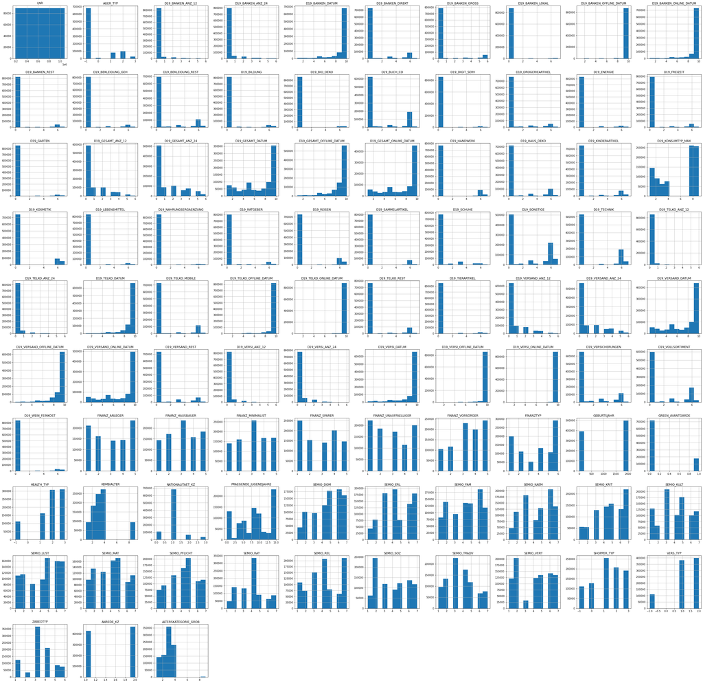

```python
azdias[df_dtypes[df_dtypes.dtype_azdias=='int64'].index].hist(figsize=(50, 50));
```

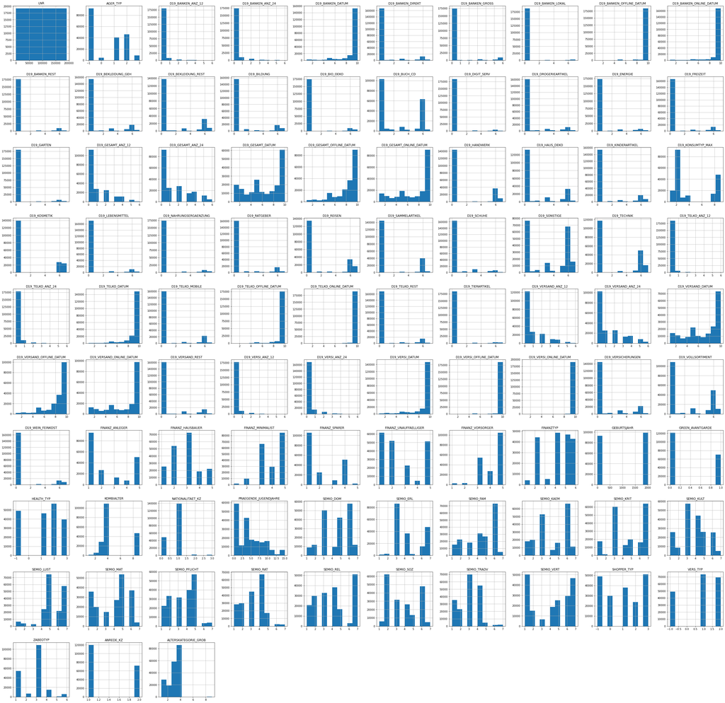

```python
customers[df_dtypes[df_dtypes.dtype_azdias=='int64'].index].hist(figsize=(50, 50));
```

```python
azdias['LNR'].describe()
```

```
count    8.912210e+05
mean     6.372630e+05
std      2.572735e+05
min      1.916530e+05
25%      4.144580e+05
50%      6.372630e+05
75%      8.600680e+05
max      1.082873e+06
Name: LNR, dtype: float64
```

```python
azdias['LNR'].nunique()
```

```
891221
```

```python
customers['LNR'].describe()
```

```
count    191652.000000
mean      95826.500000
std       55325.311233
min           1.000000
25%       47913.750000
50%       95826.500000
75%      143739.250000
max      191652.000000
Name: LNR, dtype: float64
```

```python
customers['LNR'].nunique()
```

```
191652
```

`Point One:` It looks like **LNR** is a unique value for each row in both datasets, it can be considered as a unique ID.

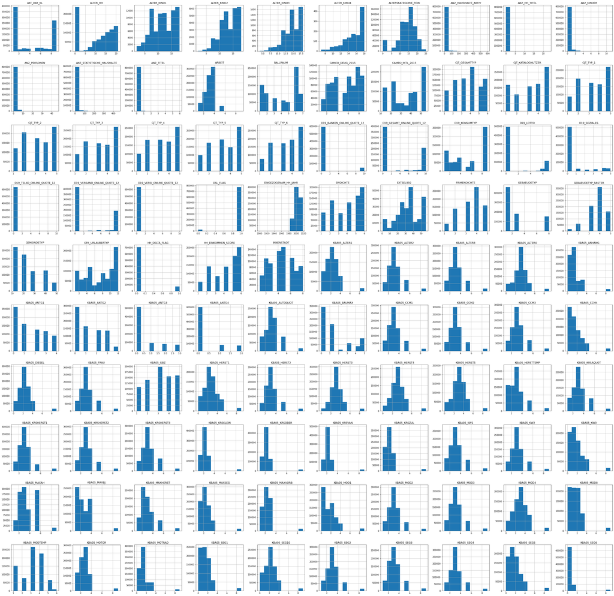

```python
azdias[df_dtypes[df_dtypes.dtype_azdias=='float64'].index[0:100]].hist(figsize=(50, 50));
```

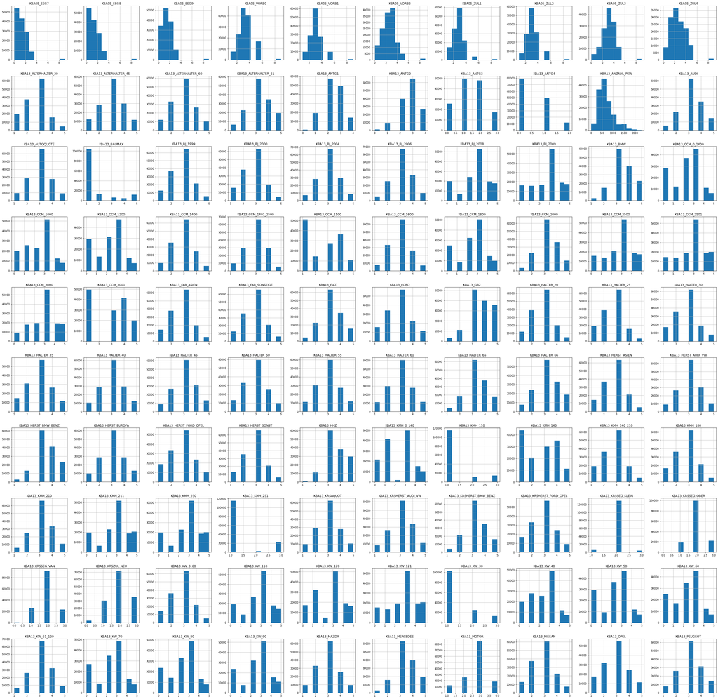

```python
# checking customers dataset only for the last 200 distributions
customers[df_dtypes[df_dtypes.dtype_azdias=='float64'].index[100:200]].hist(figsize=(50, 50));
```

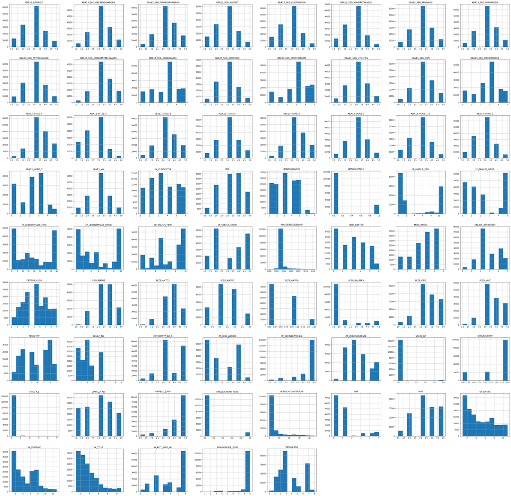

```python
customers[df_dtypes[df_dtypes.dtype_azdias=='float64'].index[200:300]].hist(figsize=(50, 50));
```

`Point Two:` The distributions for floating values are looking fine with some columns obviously containining outliers. I will leave them for now, and remove outliers in the later cleaning process.

```python
df_dtypes.value_counts()
```

```
dtype_azdias   dtype_customers  if_same
float64        float64          True       267
int64          int64            True        93
object         object           True         3
float64        float64          True         2
datetime64[s]  datetime64[s]    True         1
dtype: int64
```

#### 3. Update Unknown and Invalid Values

In this part of the data preprocessing progress, I will change the unknown and invalid values in `azdias` and `customers` to proper nan values.

`Action One:` For each column, remove the values that are not in the possible values list.

```python
azdias.head()
```

|  | LNR | AGER_TYP | AKT_DAT_KL | ALTER_HH | ALTER_KIND1 | ALTER_KIND2 | ALTER_KIND3 | ALTER_KIND4 | ALTERSKATEGORIE_FEIN | ANZ_HAUSHALTE_AKTIV | ... | VHN | VK_DHT4A | VK_DISTANZ | VK_ZG11 | W_KEIT_KIND_HH | WOHNDAUER_2008 | WOHNLAGE | ZABEOTYP | ANREDE_KZ | ALTERSKATEGORIE_GROB |
| --- | --- | --- | --- | --- | --- | --- | --- | --- | --- | --- | --- | --- | --- | --- | --- | --- | --- | --- | --- | --- | --- |
| 0 | 910215 | -1 | NaN | NaN | NaN | NaN | NaN | NaN | NaN | NaN | ... | NaN | NaN | NaN | NaN | NaN | NaN | NaN | 3 | 1 | 2 |
| 1 | 910220 | -1 | 9.0 | 0.0 | NaN | NaN | NaN | NaN | 21.0 | 11.0 | ... | 4.0 | 8.0 | 11.0 | 10.0 | 3.0 | 9.0 | 4.0 | 5 | 2 | 1 |
| 2 | 910225 | -1 | 9.0 | 17.0 | NaN | NaN | NaN | NaN | 17.0 | 10.0 | ... | 2.0 | 9.0 | 9.0 | 6.0 | 3.0 | 9.0 | 2.0 | 5 | 2 | 3 |
| 3 | 910226 | 2 | 1.0 | 13.0 | NaN | NaN | NaN | NaN | 13.0 | 1.0 | ... | 0.0 | 7.0 | 10.0 | 11.0 | NaN | 9.0 | 7.0 | 3 | 2 | 4 |
| 4 | 910241 | -1 | 1.0 | 20.0 | NaN | NaN | NaN | NaN | 14.0 | 3.0 | ... | 2.0 | 3.0 | 5.0 | 4.0 | 2.0 | 9.0 | 3.0 | 4 | 1 | 3 |

5 rows × 366 columns

```python
azdia_copy = azdias.copy()
customers_copy = customers.copy()
```

```python
possible_values
```

```
{'SEMIO_LUST': [-1, 9, 1, 2, 3, 4, 5, 6, 7],
 'W_KEIT_KIND_HH': [-1, 0, 1, 2, 3, 4, 5, 6],
 'KBA13_BJ_2009': [-1, 0, 1, 2, 3, 4, 5],
 'KBA13_BMW': [-1, 0, 1, 2, 3, 4, 5],
 'GFK_URLAUBERTYP': [1, 2, 3, 4, 5, 6, 7, 8, 9, 10, 11, 12],
 'KBA13_KW_61_120': [-1, 0, 1, 2, 3, 4, 5],
 'KBA13_KRSHERST_AUDI_VW': [-1, 0, 1, 2, 3, 4, 5],
 'PLZ8_HHZ': [-1, 1, 2, 3, 4, 5],
 'KBA13_KW_80': [-1, 0, 1, 2, 3, 4, 5],
 'KBA05_HERSTTEMP': [-1, 9, 1, 2, 3, 4, 5],
 'PLZ8_GBZ': [-1, 1, 2, 3, 4, 5],
 'D19_BANKEN_ANZ_24': [0, 1, 2, 3, 4, 5, 6],
 'KBA05_MOD8': [-1, 9, 0, 1, 2, 3],
 'LP_FAMILIE_GROB': [1, 2, 3, 4, 5, 6, 7, 8, 9, 10, 11],
 'KBA05_KW3': [-1, 9, 0, 1, 2, 3, 4],
 'ZABEOTYP': [-1, 9, 1, 2, 3, 4, 5, 6],
 'LP_STATUS_FEIN': [1, 2, 3, 4, 5, 6, 7, 8, 9, 10],
 'KBA13_BJ_2000': [-1, 0, 1, 2, 3, 4, 5],
 'ANREDE_KZ': [-1, 0, 1, 2],
 'KBA05_KW1': [-1, 9, 1, 2, 3, 4, 5],
 'LP_STATUS_GROB': [1, 2, 3, 4, 5, 6, 7, 8, 9, 10],
 'KBA05_MAXSEG': [-1, 9, 1, 2, 3, 4],
 'SEMIO_REL': [-1, 9, 1, 2, 3, 4, 5, 6, 7],
 'ALTERSKATEGORIE_GROB': [-1, 0, 1, 2, 3, 4, 9],
 'KBA13_KRSAQUOT': [-1, 0, 1, 2, 3, 4, 5],
 'KBA05_ANTG1': [-1, 0, 1, 2, 3, 4],
 'WOHNLAGE': [-1, 0, 1, 2, 3, 4, 5, 7, 8],
 'ALTER_HH': [0,
  1,
  2,
  3,
  4,
  5,
  6,
  7,
  8,
  9,
  10,
  11,
  12,
```

[output cut: 336 more lines]

```
 'OST_WEST_KZ': [-1, 'O', 'W'],
 'HEALTH_TYP': [-1, 0, 1, 2, 3],
 'KBA13_OPEL': [-1, 0, 1, 2, 3, 4, 5],
 'KBA05_ALTER2': [-1, 9, 1, 2, 3, 4, 5],
 'NATIONALITAET_KZ': [-1, 0, 1, 2, 3],
 'KBA05_ALTER3': [-1, 9, 1, 2, 3, 4, 5],
 'KBA05_FRAU': [-1, 9, 1, 2, 3, 4, 5],
 'KBA13_ALTERHALTER_45': [-1, 0, 1, 2, 3, 4, 5],
 'D19_BANKEN_ANZ_12': [0, 1, 2, 3, 4, 5, 6],
 'KBA13_SITZE_5': [-1, 0, 1, 2, 3, 4, 5],
 'KBA13_AUDI': [-1, 0, 1, 2, 3, 4, 5],
 'KBA13_VW': [-1, 0, 1, 2, 3, 4, 5],
 'KBA13_SEG_MINIVANS': [-1, 0, 1, 2, 3, 4, 5],
 'D19_VERSAND_ANZ_24': [0, 1, 2, 3, 4, 5, 6],
 'D19_VERSI_ANZ_24': [0, 1, 2, 3, 4, 5, 6]}
```

```python
#check if numerical attributes without specific range are valid
for attr, val in possible_values.items():
    if 10000 in val:
        print(attr, azdia_copy[attr].dtypes)
```

```
MIN_GEBAEUDEJAHR float64
GEBURTSJAHR int64
KBA13_ANZAHL_PKW float64
```

```python
for attr, val in possible_values.items():
    if 10000 not in val:
        azdia_copy[attr] = azdia_copy[attr].apply(lambda x: x if x in val else np.nan)
        customers_copy[attr] = customers_copy[attr].apply(lambda x: x if x in val else np.nan)
```

```python
azdia_copy.ANZ_PERSONEN.value_counts()
```

```
1.0    423383
2.0    195470
3.0     94905
Name: ANZ_PERSONEN, dtype: int64
```

```python
azdias.ANZ_PERSONEN.value_counts()
```

```
1.0     423383
2.0     195470
3.0      94905
4.0      47126
0.0      34103
5.0      15503
6.0       4842
7.0       1525
8.0        523
9.0        180
10.0        67
11.0        38
12.0        16
13.0        11
14.0         4
21.0         4
20.0         3
15.0         3
37.0         2
22.0         2
23.0         2
38.0         2
45.0         1
31.0         1
29.0         1
16.0         1
18.0         1
35.0         1
17.0         1
40.0         1
Name: ANZ_PERSONEN, dtype: int64
```

```python
attributes_values[attributes_values['Attribute']=='ANZ_PERSONEN']
```

|  | Attribute | Description | Value | Meaning |
| --- | --- | --- | --- | --- |
| 38 | ANZ_PERSONEN | number of adult persons in the household | … | numeric value (typically coded from 1-3) |

`Action Two:` For each column, remove the values that are unknow.

```python
unknown_values
```

```
{'SEMIO_LUST': [-1, 9],
 'W_KEIT_KIND_HH': [-1, 0],
 'KBA13_BJ_2009': [-1],
 'KBA13_BMW': [-1],
 'GFK_URLAUBERTYP': [],
 'KBA13_KW_61_120': [-1],
 'KBA13_KRSHERST_AUDI_VW': [-1],
 'PLZ8_HHZ': [-1],
 'KBA13_KW_80': [-1],
 'KBA05_HERSTTEMP': [-1, 9],
 'PLZ8_GBZ': [-1],
 'D19_BANKEN_ANZ_24': [],
 'KBA05_MOD8': [-1, 9],
 'LP_FAMILIE_GROB': [],
 'KBA05_KW3': [-1, 9],
 'ZABEOTYP': [-1, 9],
 'LP_STATUS_FEIN': [],
 'KBA13_BJ_2000': [-1],
 'ANREDE_KZ': [-1, 0],
 'KBA05_KW1': [-1, 9],
 'LP_STATUS_GROB': [],
 'KBA05_MAXSEG': [-1, 9],
 'SEMIO_REL': [-1, 9],
 'ALTERSKATEGORIE_GROB': [-1, 0],
 'KBA13_KRSAQUOT': [-1],
 'KBA05_ANTG1': [-1],
 'WOHNLAGE': [-1],
 'ALTER_HH': [0],
 'KBA13_SEG_SPORTWAGEN': [-1],
 'KBA13_MOTOR': [-1],
 'D19_GESAMT_OFFLINE_DATUM': [],
 'KBA05_MOD3': [-1, 9],
 'KBA05_HERST4': [-1, 9],
 'SEMIO_RAT': [-1, 9],
 'D19_TELKO_OFFLINE_DATUM': [],
 'KBA13_KMH_211': [-1],
 'KBA05_CCM4': [-1, 9],
 'MIN_GEBAEUDEJAHR': [],
 'FINANZ_ANLEGER': [-1],
 'D19_BANKEN_ONLINE_QUOTE_12': [],
```

[output cut: 217 more lines]

```
 'OST_WEST_KZ': [-1],
 'HEALTH_TYP': [-1],
 'KBA13_OPEL': [-1],
 'KBA05_ALTER2': [-1, 9],
 'NATIONALITAET_KZ': [-1, 0],
 'KBA05_ALTER3': [-1, 9],
 'KBA05_FRAU': [-1, 9],
 'KBA13_ALTERHALTER_45': [-1],
 'D19_BANKEN_ANZ_12': [],
 'KBA13_SITZE_5': [-1],
 'KBA13_AUDI': [-1],
 'KBA13_VW': [-1],
 'KBA13_SEG_MINIVANS': [-1],
 'D19_VERSAND_ANZ_24': [],
 'D19_VERSI_ANZ_24': []}
```

```python
azdia_copy.D19_BANKEN_ANZ_24.value_counts()
```

```
0    794100
1     43554
2     29079
3     10214
4      9041
5      3930
6      1303
Name: D19_BANKEN_ANZ_24, dtype: int64
```

```python
for attr, val in unknown_values.items():
    azdia_copy[attr] = azdia_copy[attr].apply(lambda x: np.nan if x in val else x)
    customers_copy[attr] = customers_copy[attr].apply(lambda x: np.nan if x in val else x)
```

```python
azdia_copy.D19_BANKEN_ANZ_24.value_counts()
```

```
0    794100
1     43554
2     29079
3     10214
4      9041
5      3930
6      1303
Name: D19_BANKEN_ANZ_24, dtype: int64
```

```python
# azdias = azdia_copy
# customers = customers_copy
```

```python
%who
```

```
att	 attr	 attributes_info	 attributes_values	 azdia_copy	 azdias	 azdias_comm_attr	 azdias_cust_comm	 customers
customers_comm_attr	 customers_copy	 df_dtypes	 invalid_attr	 key	 np	 os	 other_attr	 pd
plt	 possible_values	 sns	 sys	 unknown_values	 unknown_words	 val
```

```python
# del customers_copy
# del azdia_copy
```

#### 4. Checking Missing Values

In this part of the data preprocessing progress, I will clean `azdias` and `customers` data by checking the missing values in the dataframes.

`Step One:` Plot the distribution of miissing values for the original datasets for references.

```python
# top 15 columns with the most missing values in azdias
azdias.isnull().mean().sort_values(ascending=False)[0:15]
```

```
ALTER_KIND4                    0.998648
ALTER_KIND3                    0.993077
ALTER_KIND2                    0.966900
ALTER_KIND1                    0.909048
EXTSEL992                      0.733996
KK_KUNDENTYP                   0.655967
ALTERSKATEGORIE_FEIN           0.295041
D19_VERSAND_ONLINE_QUOTE_12    0.288495
D19_LOTTO                      0.288495
D19_BANKEN_ONLINE_QUOTE_12     0.288495
D19_LETZTER_KAUF_BRANCHE       0.288495
D19_SOZIALES                   0.288495
D19_GESAMT_ONLINE_QUOTE_12     0.288495
D19_KONSUMTYP                  0.288495
D19_VERSI_ONLINE_QUOTE_12      0.288495
dtype: float64
```

```python
# top 15 columns with the most missing values in customers
customers.isnull().mean().sort_values(ascending=False)[0:15]
```

```
ALTER_KIND4        0.998769
ALTER_KIND3        0.993347
ALTER_KIND2        0.973389
ALTER_KIND1        0.938607
KK_KUNDENTYP       0.584064
EXTSEL992          0.444989
KBA05_KRSOBER      0.292092
KBA05_KRSHERST1    0.292092
KBA05_GBZ          0.292092
KBA05_HERST1       0.292092
KBA05_HERST2       0.292092
KBA05_HERST3       0.292092
KBA05_HERST4       0.292092
KBA05_HERST5       0.292092
KBA05_KRSAQUOT     0.292092
dtype: float64
```

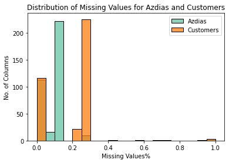

```python
plt.figure()

sns.histplot(azdias.isnull().mean(), label='Azdias', bins=20, color='#66c2a5')
sns.histplot(customers.isnull().mean(), label='Customers', bins=20, color='#ff7f0e')
plt.ylabel('No. of Columns')
plt.xlabel('Missing Values%')
plt.title('Distribution of Missing Values for Azdias and Customers')
plt.legend()
plt.show()
```

`Pint One:` From the plot, most of the columns with missing values within 30%.

```python
# sns.color_palette()
# print(sns.color_palette().as_hex())
```

`Step Two:` Plot the distribution of missing values for the updated datasets.

```python
# top 15 columns with the most missing values in azdia_copy
azdia_copy.isnull().mean().sort_values(ascending=False)[0:15]
```

```
ALTER_KIND4             0.998648
TITEL_KZ                0.997576
ANZ_TITEL               0.996432
ALTER_KIND3             0.993077
ANZ_HH_TITEL            0.973251
ALTER_KIND2             0.966900
ALTER_KIND1             0.909048
AGER_TYP                0.760196
EXTSEL992               0.733996
KK_KUNDENTYP            0.655967
KBA05_BAUMAX            0.534687
ALTER_HH                0.348137
ANZ_HAUSHALTE_AKTIV     0.306781
ALTERSKATEGORIE_FEIN    0.295041
D19_SOZIALES            0.288495
dtype: float64
```

```python
# top 15 columns with the most missing values in customers
customers_copy.isnull().mean().sort_values(ascending=False)[0:15]
```

```
ALTER_KIND4            0.998769
ALTER_KIND3            0.993347
TITEL_KZ               0.987936
ANZ_TITEL              0.985703
ALTER_KIND2            0.973389
ANZ_HH_TITEL           0.968798
ALTER_KIND1            0.938607
KK_KUNDENTYP           0.584064
KBA05_BAUMAX           0.571531
AGER_TYP               0.480595
EXTSEL992              0.444989
ANZ_PERSONEN           0.415921
ALTER_HH               0.358707
ANZ_HAUSHALTE_AKTIV    0.349055
REGIOTYP               0.313401
dtype: float64
```

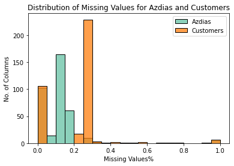

```python
plt.figure()

sns.histplot(azdia_copy.isnull().mean(), label='Azdias', bins=20, color='#66c2a5')
sns.histplot(customers_copy.isnull().mean(), label='Customers', bins=20, color='#ff7f0e')
plt.ylabel('No. of Columns')
plt.xlabel('Missing Values%')
plt.title('Distribution of Missing Values for Azdias and Customers')
plt.legend()
plt.show()
```

`Pint Two:` From the plot for the updated datasets, most of the columns with missing values are still within 30%.

`Action One:` I will drop columns with missing values larger than 50% in both Azdias and Customers datasets.

```python
set(azdia_copy.columns[azdia_copy.isnull().mean()>0.5])
```

```
{'AGER_TYP',
 'ALTER_KIND1',
 'ALTER_KIND2',
 'ALTER_KIND3',
 'ALTER_KIND4',
 'ANZ_HH_TITEL',
 'ANZ_TITEL',
 'EXTSEL992',
 'KBA05_BAUMAX',
 'KK_KUNDENTYP',
 'TITEL_KZ'}
```

```python
set(customers_copy.columns[customers_copy.isnull().mean()>0.5])
```

```
{'ALTER_KIND1',
 'ALTER_KIND2',
 'ALTER_KIND3',
 'ALTER_KIND4',
 'ANZ_HH_TITEL',
 'ANZ_TITEL',
 'KBA05_BAUMAX',
 'KK_KUNDENTYP',
 'TITEL_KZ'}
```

```python
# drop columns
azdias_drop = set(azdia_copy.columns[azdia_copy.isnull().mean()>0.5])
customers_drop = set(customers_copy.columns[customers_copy.isnull().mean()>0.5])
drop_columns = azdias_drop.union(customers_drop)
```

```python
drop_columns
```

```
{'AGER_TYP',
 'ALTER_KIND1',
 'ALTER_KIND2',
 'ALTER_KIND3',
 'ALTER_KIND4',
 'ANZ_HH_TITEL',
 'ANZ_TITEL',
 'EXTSEL992',
 'KBA05_BAUMAX',
 'KK_KUNDENTYP',
 'TITEL_KZ'}
```

```python
azdias = azdia_copy.drop(drop_columns, axis=1)
customers = customers_copy.drop(drop_columns, axis=1)
```

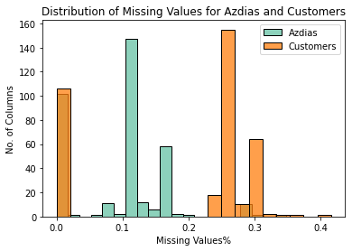

```python
plt.figure()

sns.histplot(azdias.isnull().mean(), label='Azdias', bins=20, color='#66c2a5')
sns.histplot(customers.isnull().mean(), label='Customers', bins=20, color='#ff7f0e')
plt.ylabel('No. of Columns')
plt.xlabel('Missing Values%')
plt.title('Distribution of Missing Values for Azdias and Customers')
plt.legend()
plt.show()
```

`Step Three:` Check the row-wise missing value distribution.

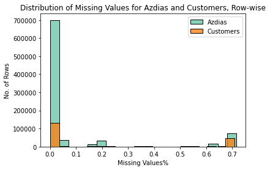

```python
plt.figure()

sns.histplot(azdias.isnull().mean(axis=1), label='Azdias', bins=20, color='#66c2a5')
sns.histplot(customers.isnull().mean(axis=1), label='Customers', bins=20, color='#ff7f0e')
plt.ylabel('No. of Rows')
plt.xlabel('Missing Values%')
plt.title('Distribution of Missing Values for Azdias and Customers, Row-wise')
plt.legend()
plt.show()
```

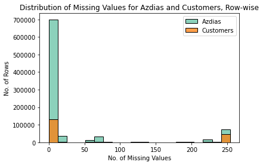

```python
plt.figure()

sns.histplot(azdias.isnull().sum(axis=1), label='Azdias', bins=20, color='#66c2a5')
sns.histplot(customers.isnull().sum(axis=1), label='Customers', bins=20, color='#ff7f0e')
plt.ylabel('No. of Rows')
plt.xlabel('No. of Missing Values')
plt.title('Distribution of Missing Values for Azdias and Customers, Row-wise')
plt.legend()
plt.show()
```

`Pint Three:` From the plot, most of the rows with no more than 50 or 10% of missing values.

`Action Three:` Drop all the rows which have more than 50 missing values.

```python
azdias_temp = azdias.dropna(thresh=azdias.shape[1]-50)
customers_temp = customers.dropna(thresh=customers.shape[1]-50)
```

```python
print('Azdias dataset removed {} rows'.format(azdias.shape[0]-azdias_temp.shape[0]))
print('Customers dataset removed {} rows'.format(customers.shape[0]-customers_temp.shape[0]))
```

```
Azdias dataset removed 153933 rows
Customers dataset removed 57406 rows
```

```python
# reset index
azdias = azdias_temp.reset_index(drop=True)
customers = customers_temp.reset_index(drop=True)
```

```python
%who
```

```
att	 attr	 attributes_info	 attributes_values	 azdia_copy	 azdias	 azdias_comm_attr	 azdias_cust_comm	 azdias_drop
azdias_temp	 customers	 customers_comm_attr	 customers_copy	 customers_drop	 customers_temp	 df_dtypes	 drop_columns	 invalid_attr
key	 np	 os	 other_attr	 pd	 plt	 possible_values	 sns	 sys
unknown_values	 unknown_words	 val
```

#### 5. Save Data

In this part, I will save the cleaned datasets into csv files.

```python
azdias.head()
```

|  | LNR | AKT_DAT_KL | ALTER_HH | ALTERSKATEGORIE_FEIN | ANZ_HAUSHALTE_AKTIV | ANZ_KINDER | ANZ_PERSONEN | ANZ_STATISTISCHE_HAUSHALTE | ARBEIT | BALLRAUM | ... | VHN | VK_DHT4A | VK_DISTANZ | VK_ZG11 | W_KEIT_KIND_HH | WOHNDAUER_2008 | WOHNLAGE | ZABEOTYP | ANREDE_KZ | ALTERSKATEGORIE_GROB |
| --- | --- | --- | --- | --- | --- | --- | --- | --- | --- | --- | --- | --- | --- | --- | --- | --- | --- | --- | --- | --- | --- |
| 0 | 910220 | 9.0 | NaN | 21.0 | NaN | 0.0 | 2.0 | 12.0 | 3.0 | 6.0 | ... | 4.0 | 8.0 | 11.0 | 10.0 | 3.0 | 9.0 | 4.0 | 5 | 2 | 1 |
| 1 | 910225 | 9.0 | 17.0 | 17.0 | 10.0 | 0.0 | 1.0 | 7.0 | 3.0 | 2.0 | ... | 2.0 | 9.0 | 9.0 | 6.0 | 3.0 | 9.0 | 2.0 | 5 | 2 | 3 |
| 2 | 910226 | 1.0 | 13.0 | 13.0 | 1.0 | 0.0 | NaN | 2.0 | 2.0 | 4.0 | ... | 0.0 | 7.0 | 10.0 | 11.0 | NaN | 9.0 | 7.0 | 3 | 2 | 4 |
| 3 | 910241 | 1.0 | 20.0 | 14.0 | 3.0 | 0.0 | NaN | 3.0 | 4.0 | 2.0 | ... | 2.0 | 3.0 | 5.0 | 4.0 | 2.0 | 9.0 | 3.0 | 4 | 1 | 3 |
| 4 | 910244 | 1.0 | 10.0 | 10.0 | 5.0 | 0.0 | 1.0 | 2.0 | 2.0 | 6.0 | ... | 2.0 | 10.0 | 7.0 | 4.0 | 6.0 | 9.0 | 7.0 | 4 | 2 | 1 |

5 rows × 355 columns

```python
customers.head()
```

|  | LNR | AKT_DAT_KL | ALTER_HH | ALTERSKATEGORIE_FEIN | ANZ_HAUSHALTE_AKTIV | ANZ_KINDER | ANZ_PERSONEN | ANZ_STATISTISCHE_HAUSHALTE | ARBEIT | BALLRAUM | ... | VK_ZG11 | W_KEIT_KIND_HH | WOHNDAUER_2008 | WOHNLAGE | ZABEOTYP | PRODUCT_GROUP | CUSTOMER_GROUP | ONLINE_PURCHASE | ANREDE_KZ | ALTERSKATEGORIE_GROB |
| --- | --- | --- | --- | --- | --- | --- | --- | --- | --- | --- | --- | --- | --- | --- | --- | --- | --- | --- | --- | --- | --- |
| 0 | 9626 | 1.0 | 10.0 | 10.0 | 1.0 | 0.0 | 2.0 | 1.0 | 1.0 | 3.0 | ... | 2.0 | 6.0 | 9.0 | 7.0 | 3 | COSMETIC_AND_FOOD | MULTI_BUYER | 0 | 1 | 4 |
| 1 | 143872 | 1.0 | 6.0 | 0.0 | 1.0 | 0.0 | 1.0 | 1.0 | 3.0 | 7.0 | ... | 11.0 | 6.0 | 9.0 | 2.0 | 3 | COSMETIC_AND_FOOD | MULTI_BUYER | 0 | 2 | 4 |
| 2 | 143873 | 1.0 | 8.0 | 8.0 | NaN | 0.0 | NaN | 1.0 | 1.0 | 7.0 | ... | 2.0 | NaN | 9.0 | 7.0 | 1 | COSMETIC | MULTI_BUYER | 0 | 1 | 4 |
| 3 | 143874 | 1.0 | 20.0 | 14.0 | 7.0 | 0.0 | NaN | 7.0 | 3.0 | 3.0 | ... | 4.0 | 2.0 | 9.0 | 3.0 | 1 | FOOD | MULTI_BUYER | 0 | 1 | 3 |
| 4 | 143888 | 1.0 | 11.0 | 10.0 | 1.0 | 0.0 | 2.0 | 1.0 | 3.0 | 7.0 | ... | 1.0 | 6.0 | 9.0 | 1.0 | 2 | COSMETIC_AND_FOOD | MULTI_BUYER | 0 | 1 | 3 |

5 rows × 358 columns

```python
azdias.to_csv('./data/azdias_cleaned.csv')
customers.to_csv('./data/customers_cleaned.csv')
```